# Creación de modelos para Glioblastoma

```r
library(mlbench)
library(caret)
library(corrplot)
library(e1071)
library(MLmetrics)
library(smotefamily)
library(openxlsx)
library(cvms)
```

Este documento explica el proceso de creación de un modelo basado en Machine Learning (ML) para predecir el estado vital del paciente (vivo/muerto) a los 12 meses para pacientes con Glioblastoma (GBM). Esto se realiza basándose en metadatos de los pacientes y características extraídas de imágenes MRI.

## Cargar datos y librerías

Se cargan los datos y se dividen en datasets de entrenamiento (train) y validación (test). Los datos cargados se corresponden al dataset empleado para la estimación de la curva de supervivencia, por lo que el proceso de EDA y parte del pre-procesamiento ya ha sido llevado a cabo previamente.

```r
load(file = 'dataset_images_12month_features_completed.Rda')
gbm_dataset <- dataset_images_12month_features_completed
gbm_dataset <- gbm_dataset[, -which(names(gbm_dataset) == 'time_monitored', arr.ind = TRUE)]

# Dividir los datos
set.seed(7)
validationIndex <- createDataPartition(gbm_dataset$vital_status_at_12months_follow_up, p=0.80, list=FALSE)
# Seleccionar el 20% de los datos para la validación
gbm_dataset_v <- gbm_dataset[-validationIndex,]
# Usar el 80% restante para el entrenamiento de los modelos
gbm_dataset <- gbm_dataset[validationIndex,]
```

## EDA

Aunque este paso ya ha sido realizado en el análisis de riesgos, se va a analizar el balanceo de los datasets creados y las características de las variables. La variable de clase es el estado vital de los pacientes a los 12 meses (vital_status_at_12months_follow_up) y tiene dos posibles valores: vivo (Living) o muerto (Deceased).

```
[1] "Verificar el balanceo de clase del dataset de training"
         Level_freq Level_percent
Deceased         17      43.58974
Living           22      56.41026
[1] "Verificar el balanceo de clase del dataset de testing"
         Level_freq Level_percent
Deceased          4      44.44444
Living            5      55.55556
[1] "Verificar datos NA"
[1] 0
```

## Dataset preprocessing

Para la creación de los modelos de predicción se ha decidido crear 3 vistas distintas, las cuales se describen a continuación.

- Dataset con PCA aplicado para la reducción de la dimensionalidad.
- Dataset tal y como se ha aplicado para la creación de la curva de supervivencia.
- Dataset solo con las variables que se han determinado como factores de riesgo en el análisis de la curva de supervivencia.

Se aplicará PCA al dataset de entrenamiento en primer lugar.

```r
numeric_vars_index <- c(which(sapply(gbm_dataset, class) == 'numeric', arr.ind = TRUE), which(sapply(gbm_dataset, class) == 'integer', arr.ind = TRUE))
non_numeric_vars_index <- which(sapply(gbm_dataset, class) == 'factor', arr.ind = TRUE)

pr.out.train <- prcomp(gbm_dataset[, numeric_vars_index], scale = TRUE)
biplot(pr.out.train, scale=0)

pr.var <- pr.out.train$sdev^2
pve <- pr.var / sum(pr.var)
pve
```

```
 [1] 3.189780e-01 1.571358e-01 9.257238e-02 7.416031e-02 6.150679e-02 5.798768e-02 4.188210e-02 3.899998e-02 3.040769e-02 2.602442e-02
[11] 2.369599e-02 2.220190e-02 1.782207e-02 1.094428e-02 1.020969e-02 8.226468e-03 5.480154e-03 1.713963e-03 4.880883e-05 9.665119e-07
[21] 2.220027e-07 1.471512e-07 1.243706e-07 9.543203e-13 1.723990e-13 4.045361e-21
```

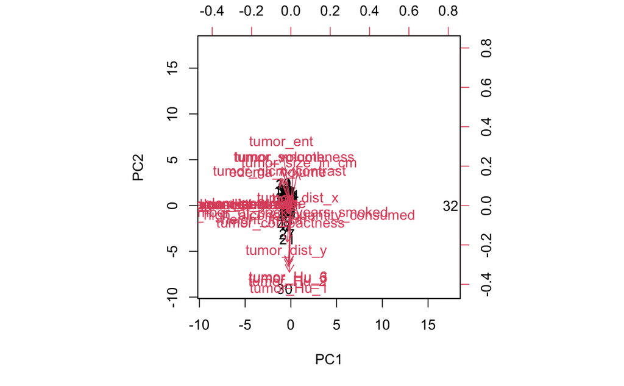

```r
par(mfrow=c(1,2))
```

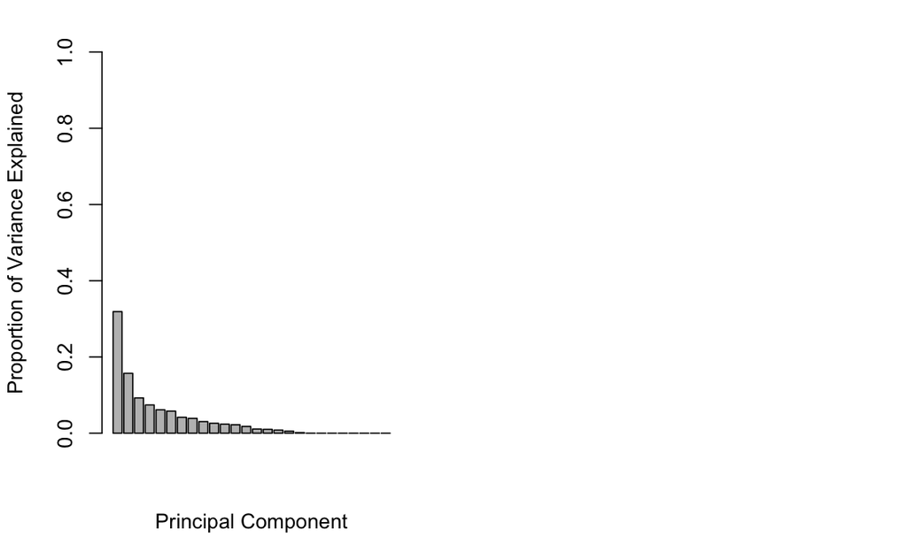

```r
barplot(pve, xlab='Principal Component', ylab='Proportion of Variance Explained', ylim=c(0,1))
plot(cumsum(pve), xlab='Principal Component', ylab='Cumuative Proportion of Variance Explained', ylim=c(0,1))
```

```r
preprocessParams <- preProcess(gbm_dataset[, numeric_vars_index], method=c("pca"))
print(preprocessParams)
```

```
Created from 39 samples and 26 variables

Pre-processing:
  - centered (26)
  - ignored (0)
  - principal component signal extraction (26)
  - scaled (26)

PCA needed 13 components to capture 95 percent of the variance
```

```r
gbm_dataset_PCA <- pr.out.train$x[,1:preprocessParams$numComp]
gbm_dataset_PCA <- as.data.frame(cbind(gbm_dataset_PCA, gbm_dataset[,non_numeric_vars_index]))
```

También se crea una tercera vista del dataset con los factores de riesgo identificados.

```r
risk_factors <- c("alcohol_consumption", "age", "bmi", "tobacco_smoking_history", "tumor_Hu_3", "edema_glcm_correlation", "tumor_size_in_cm", "height_in_cm", "tumor_ent", "tumor_Hu_2", "tumor_Hu_6", "gender", "tumor_glcm_contrast", "tumor_smoothness")

risk_factor_indexes <- c()
for (i in 1:length(risk_factors)){
  risk_factor_indexes[i] = which(colnames(gbm_dataset) == risk_factors[i], arr.ind = TRUE)
}

gbm_dataset_risk <- gbm_dataset[,risk_factor_indexes]
gbm_dataset_risk$vital_status_at_12months_follow_up <- gbm_dataset$vital_status_at_12months_follow_up
```

## Creación de modelos

Para cada una de las vistas definida se han creado 5 modelos distintos empleando 5 algoritmos (SVM, KNN, Random Forest, Boosting y Regresión Logística). Se ha aplicado la técnica “repeatedcv” para tener más datos para evaluar los algoritmos y así poder realizar una comparación más completa. Todos los algoritmos, menos el de Regresión Logística, han sido modificados para que los parámetros que emplee no sean únicamente los definidos por defecto.

```r
control <- trainControl(method="repeatedcv", number = 5, repeats = 3, classProbs = TRUE, summaryFunction = multiClassSummary)

grid <- expand.grid(sigma = c(1:8) * 0.03194379, C = c(1:10)*0.25)
set.seed(7)
fit.svm.PCA <- train(vital_status_at_12months_follow_up~., data=gbm_dataset_PCA, method="svmRadial", metric="ROC", trControl=control, tuneGrid = grid)
print('Algoritmo SVM con el dataset PCA')
```

```
[1] "Algoritmo SVM con el dataset PCA"
```

```r
print(fit.svm.PCA)
```

```
Support Vector Machines with Radial Basis Function Kernel

39 samples
16 predictors
 2 classes: 'Deceased', 'Living'

No pre-processing
Resampling: Cross-Validated (5 fold, repeated 3 times)
Summary of sample sizes: 32, 30, 32, 31, 31, 31, ...
Resampling results across tuning parameters:

  sigma       C     logLoss    AUC        prAUC      Accuracy   Kappa         F1         Sensitivity  Specificity  Pos_Pred_Value
  0.03194379  0.25  0.7773618  0.3975000  0.4059640  0.4869048  -0.068695416  0.5246341  0.31111111   0.6266667    0.3175000
  0.03194379  0.50  0.7239608  0.4975000  0.4457520  0.5730159   0.102358358  0.5436508  0.35000000   0.7566667    0.5177489
  0.03194379  0.75  0.7194407  0.5019444  0.4471402  0.5070106  -0.073253562  0.5289683  0.17777778   0.7600000    0.2031746
  0.03194379  1.00  0.7204317  0.5836111  0.4754444  0.5560847   0.054641816  0.5210884  0.26666667   0.7900000    0.4910714
  0.03194379  1.25  0.7179338  0.5230556  0.4604497  0.5310847   0.002118248  0.4998677  0.23333333   0.7733333    0.3458333
  0.03194379  1.50  0.7167650  0.4780556  0.4287242  0.4941799  -0.087012187  0.5069444  0.16666667   0.7500000    0.2208333
  0.03194379  1.75  0.7357696  0.4113889  0.3972649  0.5034392  -0.067051324  0.4138889  0.17777778   0.7600000    0.3348214
  0.03194379  2.00  0.7249836  0.5380556  0.4621009  0.4941799  -0.071034344  0.4960317  0.22222222   0.7166667    0.3116883
  0.03194379  2.25  0.7093317  0.5347222  0.4599292  0.4691799  -0.131903909  0.5238095  0.13333333   0.7433333    0.1587302
  0.03194379  2.50  0.7240938  0.4163889  0.4080823  0.5037037  -0.085233862  0.4375000  0.11666667   0.8000000    0.2333333
  0.06388758  0.25  0.7238600  0.5561111  0.4706524  0.5310847   0.005707861  0.5518519  0.27777778   0.7333333    0.3654762
  0.06388758  0.50  0.7590467  0.4583333  0.4352345  0.4814815  -0.098700596  0.4514911  0.23888889   0.6666667    0.2633598
  0.06388758  0.75  0.7152756  0.5894444  0.4830374  0.5551587   0.046289747  0.5238095  0.28888889   0.7633333    0.4910714
  0.06388758  1.00  0.7050133  0.5883333  0.4828955  0.5575397   0.060002617  0.5794785  0.33333333   0.7366667    0.4389881
  0.06388758  1.25  0.7106034  0.5805556  0.4830020  0.4682540  -0.125246108  0.5022222  0.20555556   0.6800000    0.2571429
  0.06388758  1.50  0.7053996  0.5505556  0.4678882  0.4888889  -0.068905108  0.5278912  0.30555556   0.6366667    0.2889610
  0.06388758  1.75  0.7002634  0.5705556  0.4815394  0.4939153  -0.073548040  0.4879819  0.25555556   0.6800000    0.3523810
  0.06388758  2.00  0.7200447  0.4916667  0.4339947  0.4917989  -0.065314064  0.4961451  0.27777778   0.6633333    0.3145238
  0.06388758  2.25  0.7116049  0.5461111  0.4611925  0.4710317  -0.102314143  0.5007937  0.25000000   0.6566667    0.2595238
  0.06388758  2.50  0.7112679  0.4786111  0.4226806  0.4615079  -0.169189665  0.3916667  0.11111111   0.7266667    0.2222222
  0.09583137  0.25  0.7184162  0.5338889  0.4597778  0.5447090   0.031330947  0.5489796  0.31111111   0.7266667    0.4202381
  0.09583137  0.50  0.6929296  0.6405556  0.5157163  0.5206349  -0.023484562  0.5034392  0.24444444   0.7400000    0.3327381
  0.09583137  0.75  0.6969655  0.5938889  0.4946402  0.5458995   0.030020635  0.4914966  0.26666667   0.7700000    0.4619048
  0.09583137  1.00  0.7173291  0.6016667  0.4925218  0.5458995   0.056486672  0.5234921  0.40000000   0.6633333    0.4589286
  0.09583137  1.25  0.6981676  0.5383333  0.4647371  0.5194444  -0.018027337  0.5748677  0.28888889   0.7033333    0.3328042
  0.09583137  1.50  0.7104057  0.5016667  0.4457126  0.5723545   0.116913698  0.6292769  0.42777778   0.6966667    0.5071429
  0.09583137  1.75  0.7094058  0.5616667  0.4719841  0.5194444  -0.042438111  0.5386243  0.14444444   0.8200000    0.2657143
  0.09583137  2.00  0.7079755  0.5727778  0.4808674  0.5444444   0.017157849  0.6279365  0.23888889   0.7866667    0.3744048
```

[output cut: 86 more lines]

```
  0.6395503       0.5370370  0.33333333  0.14576720      0.5633333
  0.6716138       0.6145833  0.35555556  0.15912698      0.6044444
  0.6584921       0.5992063  0.32222222  0.13928571      0.5627778
  0.6510053       0.5178571  0.36111111  0.15740741      0.5672222
  0.6049206       0.3439153  0.24444444  0.11071429      0.5155556
  0.6489683       0.4806548  0.32222222  0.13928571      0.5627778
  0.6416931       0.4921769  0.31111111  0.13650794      0.5472222
  0.5908995       0.3809524  0.18888889  0.08809524      0.5227778
  0.6050265       0.3973214  0.26666667  0.12023810      0.5166667
  0.6537302       0.4742063  0.29444444  0.12380952      0.5472222
  0.5808201       0.2777778  0.14444444  0.06428571      0.4855556
 [ reached getOption("max.print") -- omitted 18 rows ]

logLoss was used to select the optimal model using the smallest value.
The final values used for the model were sigma = 0.1916627 and C = 0.75.
```

```r
grid <- expand.grid(k = c(2:7)*2 - 1)
set.seed(7)
fit.knn.PCA <- train(vital_status_at_12months_follow_up~., data=gbm_dataset_PCA, method="knn", metric="ROC", trControl=control, tuneGrid = grid)
print('Algoritmo KNN con el dataset PCA')
```

```
[1] "Algoritmo KNN con el dataset PCA"
```

```r
print(fit.knn.PCA)
```

```
k-Nearest Neighbors

39 samples
16 predictors
 2 classes: 'Deceased', 'Living'

No pre-processing
Resampling: Cross-Validated (5 fold, repeated 3 times)
Summary of sample sizes: 32, 30, 32, 31, 31, 31, ...
Resampling results across tuning parameters:

  k   logLoss    AUC        prAUC      Accuracy   Kappa         F1         Sensitivity  Specificity  Pos_Pred_Value  Neg_Pred_Value
   3  6.0647238  0.5456944  0.2957401  0.5208995  -0.019845966  0.4761905  0.26111111   0.7233333    0.4285714       0.5837302
   5  2.7520431  0.6123611  0.4010503  0.5494709   0.024824758  0.5187500  0.23888889   0.7900000    0.4357143       0.5921429
   7  2.1131233  0.6554167  0.4390681  0.5220899  -0.034078860  0.4768707  0.17777778   0.7900000    0.3928571       0.5562698
   9  0.9377743  0.6583333  0.4452321  0.5649471   0.043097017  0.5530612  0.21111111   0.8366667    0.4230769       0.5866667
  11  0.6649864  0.6497222  0.4496448  0.5563492   0.017743773  0.4904762  0.17222222   0.8500000    0.4230769       0.5743651
  13  0.6773639  0.6019444  0.3974603  0.5563492   0.001622252  0.4500000  0.07777778   0.9266667    0.4444444       0.5664021
  Precision  Recall      Detection_Rate  Balanced_Accuracy
  0.4285714  0.26111111  0.11388889      0.4922222
  0.4357143  0.23888889  0.10555556      0.5144444
  0.3928571  0.17777778  0.07817460      0.4838889
  0.4230769  0.21111111  0.09484127      0.5238889
  0.4230769  0.17222222  0.07791005      0.5111111
  0.4444444  0.07777778  0.03478836      0.5022222

logLoss was used to select the optimal model using the smallest value.
The final value used for the model was k = 11.
```

```r
grid <- expand.grid(mtry = c(2, 11, 20, c(1:7)*10))
set.seed(7)
fit.rf.PCA <- train(vital_status_at_12months_follow_up~., data=gbm_dataset_PCA, method="rf", metric="ROC", trControl=control, tuneGrid = grid)
print('Algoritmo random forest con el dataset PCA')
```

```
[1] "Algoritmo random forest con el dataset PCA"
```

```r
print(fit.rf.PCA)
```

```
Random Forest

39 samples
16 predictors
 2 classes: 'Deceased', 'Living'

No pre-processing
Resampling: Cross-Validated (5 fold, repeated 3 times)
Summary of sample sizes: 32, 30, 32, 31, 31, 31, ...
Resampling results across tuning parameters:

  mtry  logLoss    AUC        prAUC      Accuracy   Kappa       F1         Sensitivity  Specificity  Pos_Pred_Value  Neg_Pred_Value
   2    0.6533842  0.6383333  0.4848208  0.5292328  0.01913721  0.4379121  0.3555556    0.6633333    0.4377778       0.5661905
  10    0.6440412  0.6227778  0.4884319  0.5628307  0.09620771  0.4998168  0.4166667    0.6800000    0.5000000       0.6065079
  11    0.6444714  0.6544444  0.4974894  0.5708995  0.10634281  0.4970696  0.4166667    0.6933333    0.5000000       0.6138889
  20    0.6515408  0.6619444  0.5058194  0.5613757  0.09413126  0.4506803  0.4000000    0.6966667    0.5444444       0.6045238
  30    0.6500788  0.6608333  0.5063433  0.5783069  0.12619360  0.4985348  0.4333333    0.7000000    0.5255556       0.6438095
  40    0.6438559  0.6744444  0.4989041  0.5783069  0.12810917  0.4816327  0.4333333    0.6966667    0.5288889       0.6234921
  50    0.6511268  0.6650000  0.4987169  0.5761905  0.12321701  0.5034799  0.4277778    0.7000000    0.5300000       0.6271429
  60    0.6528251  0.6600000  0.5076032  0.5771164  0.12065029  0.4890110  0.4111111    0.7133333    0.5400000       0.6223016
  70    0.6508257  0.6630556  0.5064868  0.5771164  0.12079692  0.4930403  0.4111111    0.7133333    0.5288889       0.6215873
  Precision  Recall     Detection_Rate  Balanced_Accuracy
  0.4377778  0.3555556  0.1546296       0.5094444
  0.5000000  0.4166667  0.1798942       0.5483333
  0.5000000  0.4166667  0.1796296       0.5550000
  0.5444444  0.4000000  0.1712963       0.5483333
  0.5255556  0.4333333  0.1870370       0.5666667
  0.5288889  0.4333333  0.1870370       0.5650000
  0.5300000  0.4277778  0.1849206       0.5638889
  0.5400000  0.4111111  0.1775132       0.5622222
  0.5288889  0.4111111  0.1775132       0.5622222

logLoss was used to select the optimal model using the smallest value.
The final value used for the model was mtry = 40.
```

```r
grid <- expand.grid(nrounds = c(1, 200, 400), max_depth = c(2:10),
                    eta = 0.3, gamma = 0,
                    colsample_bytree = 1, min_child_weight = 1,
                    subsample = 1)
set.seed(7)
fit.boost.PCA <- train(vital_status_at_12months_follow_up~., data=gbm_dataset_PCA, method="xgbTree", metric="ROC", trControl=control, tuneGrid = grid)
print('Algoritmo de boosting con el dataset PCA')
```

```
[1] "Algoritmo de boosting con el dataset PCA"
```

```r
print(fit.boost.PCA)
```

```
eXtreme Gradient Boosting

39 samples
16 predictors
 2 classes: 'Deceased', 'Living'

No pre-processing
Resampling: Cross-Validated (5 fold, repeated 3 times)
Summary of sample sizes: 32, 30, 32, 31, 31, 31, ...
Resampling results across tuning parameters:

  max_depth  nrounds  logLoss    AUC        prAUC      Accuracy   Kappa       F1         Sensitivity  Specificity  Pos_Pred_Value
   2           1      0.6479424  0.7122222  0.2633909  0.6166667  0.23045371  0.6138889  0.6444444    0.6000000    0.5300000
   2         200      1.0444112  0.5483333  0.4545813  0.5161376  0.01240141  0.4606227  0.4222222    0.5900000    0.4261905
   2         400      1.0497919  0.5316667  0.4436554  0.5235450  0.02855526  0.4743590  0.4388889    0.5900000    0.4321429
   3           1      0.6470407  0.7213889  0.3203485  0.6552910  0.30807541  0.6198413  0.7111111    0.6166667    0.5733333
   3         200      1.0082431  0.5588889  0.4624788  0.5425926  0.07882188  0.5048840  0.4888889    0.5933333    0.4820513
   3         400      1.0189194  0.5644444  0.4642381  0.5425926  0.07882188  0.5048840  0.4888889    0.5933333    0.4820513
   4           1      0.6470407  0.7213889  0.3203485  0.6552910  0.30807541  0.6198413  0.7111111    0.6166667    0.5733333
   4         200      1.0053173  0.5533333  0.4552566  0.5425926  0.07882188  0.5048840  0.4888889    0.5933333    0.4820513
   4         400      1.0229984  0.5477778  0.4534974  0.5425926  0.07882188  0.5048840  0.4888889    0.5933333    0.4820513
   5           1      0.6470407  0.7213889  0.3203485  0.6552910  0.30807541  0.6198413  0.7111111    0.6166667    0.5733333
   5         200      1.0053173  0.5533333  0.4552566  0.5425926  0.07882188  0.5048840  0.4888889    0.5933333    0.4820513
   5         400      1.0229984  0.5477778  0.4534974  0.5425926  0.07882188  0.5048840  0.4888889    0.5933333    0.4820513
   6           1      0.6470407  0.7213889  0.3203485  0.6552910  0.30807541  0.6198413  0.7111111    0.6166667    0.5733333
   6         200      1.0053173  0.5533333  0.4552566  0.5425926  0.07882188  0.5048840  0.4888889    0.5933333    0.4820513
   6         400      1.0229984  0.5477778  0.4534974  0.5425926  0.07882188  0.5048840  0.4888889    0.5933333    0.4820513
   7           1      0.6470407  0.7213889  0.3203485  0.6552910  0.30807541  0.6198413  0.7111111    0.6166667    0.5733333
   7         200      1.0053173  0.5533333  0.4552566  0.5425926  0.07882188  0.5048840  0.4888889    0.5933333    0.4820513
   7         400      1.0229984  0.5477778  0.4534974  0.5425926  0.07882188  0.5048840  0.4888889    0.5933333    0.4820513
   8           1      0.6470407  0.7213889  0.3203485  0.6552910  0.30807541  0.6198413  0.7111111    0.6166667    0.5733333
   8         200      1.0053173  0.5533333  0.4552566  0.5425926  0.07882188  0.5048840  0.4888889    0.5933333    0.4820513
   8         400      1.0229984  0.5477778  0.4534974  0.5425926  0.07882188  0.5048840  0.4888889    0.5933333    0.4820513
   9           1      0.6470407  0.7213889  0.3203485  0.6552910  0.30807541  0.6198413  0.7111111    0.6166667    0.5733333
   9         200      1.0053173  0.5533333  0.4552566  0.5425926  0.07882188  0.5048840  0.4888889    0.5933333    0.4820513
   9         400      1.0229984  0.5477778  0.4534974  0.5425926  0.07882188  0.5048840  0.4888889    0.5933333    0.4820513
  10           1      0.6470407  0.7213889  0.3203485  0.6552910  0.30807541  0.6198413  0.7111111    0.6166667    0.5733333
  10         200      1.0053173  0.5533333  0.4552566  0.5425926  0.07882188  0.5048840  0.4888889    0.5933333    0.4820513
  10         400      1.0229984  0.5477778  0.4534974  0.5425926  0.07882188  0.5048840  0.4888889    0.5933333    0.4820513
  Neg_Pred_Value  Precision  Recall     Detection_Rate  Balanced_Accuracy
```

[output cut: 23 more lines]

```
  0.6039683       0.4820513  0.4888889  0.2101852       0.5411111
  0.7733333       0.5733333  0.7111111  0.3047619       0.6638889
  0.6039683       0.4820513  0.4888889  0.2101852       0.5411111
  0.6039683       0.4820513  0.4888889  0.2101852       0.5411111

Tuning parameter 'eta' was held constant at a value of 0.3
Tuning parameter 'gamma' was held constant at a value of 0
Tuning
 parameter 'colsample_bytree' was held constant at a value of 1
Tuning parameter 'min_child_weight' was held constant at a value of 1

Tuning parameter 'subsample' was held constant at a value of 1
logLoss was used to select the optimal model using the smallest value.
The final values used for the model were nrounds = 1, max_depth = 3, eta = 0.3, gamma = 0, colsample_bytree = 1, min_child_weight = 1
 and subsample = 1.
```

```r
set.seed(7)
fit.logreg.PCA <- train(vital_status_at_12months_follow_up~., data=gbm_dataset_PCA, method="LMT", metric="ROC", trControl=control)
print('Algoritmo de regresión logística con el dataset PCA')
```

```
[1] "Algoritmo de regresión logística con el dataset PCA"
```

```r
print(fit.logreg.PCA)
```

```
Logistic Model Trees

39 samples
16 predictors
 2 classes: 'Deceased', 'Living'

No pre-processing
Resampling: Cross-Validated (5 fold, repeated 3 times)
Summary of sample sizes: 32, 30, 32, 31, 31, 31, ...
Resampling results across tuning parameters:

  iter  logLoss   AUC        prAUC      Accuracy   Kappa        F1         Sensitivity  Specificity  Pos_Pred_Value  Neg_Pred_Value
   1    0.839790  0.6319444  0.4837407  0.5661376   0.11577532  0.5064059  0.5166667    0.6066667    0.4700000       0.6633333
  21    3.200482  0.5211111  0.4529666  0.4935185  -0.02776969  0.4576923  0.4000000    0.5700000    0.4511111       0.5606349
  41    3.204152  0.5455556  0.4078578  0.4797619  -0.06089683  0.4888167  0.3888889    0.5533333    0.3488889       0.5177778
  Precision  Recall     Detection_Rate  Balanced_Accuracy
  0.4700000  0.5166667  0.2244709       0.5616667
  0.4511111  0.4000000  0.1703704       0.4850000
  0.3488889  0.3888889  0.1661376       0.4711111

logLoss was used to select the optimal model using the smallest value.
The final value used for the model was iter = 1.
```

```r
control <- trainControl(method="repeatedcv", number = 5, repeats = 3, classProbs = TRUE, summaryFunction = multiClassSummary)

grid <- expand.grid(sigma = c(1:8) * 0.02529123, C = c(1:10)*0.25)
set.seed(7)
fit.svm <- train(vital_status_at_12months_follow_up~., data=gbm_dataset, method="svmRadial", metric="ROC", trControl=control, tuneGrid = grid)
print('Algoritmo SVM con el dataset sin variables correlacionadas')
```

```
[1] "Algoritmo SVM con el dataset sin variables correlacionadas"
```

```r
print(fit.svm)
```

```
Support Vector Machines with Radial Basis Function Kernel

39 samples
29 predictors
 2 classes: 'Deceased', 'Living'

No pre-processing
Resampling: Cross-Validated (5 fold, repeated 3 times)
Summary of sample sizes: 32, 30, 32, 31, 31, 31, ...
Resampling results across tuning parameters:

  sigma       C     logLoss    AUC        prAUC      Accuracy   Kappa          F1         Sensitivity  Specificity  Pos_Pred_Value
  0.02529123  0.25  0.7581985  0.5518056  0.3357249  0.5468254   0.0218789728  0.5007937  0.23888889   0.7866667    0.4603175
  0.02529123  0.50  0.7165295  0.5406944  0.3401832  0.5384921   0.0287104124  0.4470899  0.28333333   0.7500000    0.4261905
  0.02529123  0.75  0.7001768  0.5529167  0.3354802  0.5468254   0.0340276442  0.5625850  0.31111111   0.7300000    0.3920635
  0.02529123  1.00  0.7060754  0.5784722  0.3490093  0.5396825   0.0236537289  0.4626984  0.26666667   0.7600000    0.4624339
  0.02529123  1.25  0.7056857  0.5095833  0.3200198  0.5394180   0.0236550346  0.4363095  0.24444444   0.7833333    0.4550265
  0.02529123  1.50  0.7014102  0.5459722  0.3394557  0.5013228  -0.0511934503  0.4272109  0.21111111   0.7433333    0.3595238
  0.02529123  1.75  0.7120431  0.5426389  0.3366978  0.5203704  -0.0257414144  0.4914286  0.18888889   0.7933333    0.3035714
  0.02529123  2.00  0.7168422  0.4823611  0.3088776  0.5037037  -0.0629601860  0.4928571  0.15000000   0.7966667    0.2698413
  0.02529123  2.25  0.7106830  0.5690278  0.3520218  0.5456349   0.0176285490  0.4952381  0.20000000   0.8233333    0.4179894
  0.02529123  2.50  0.7034222  0.5156944  0.3236052  0.5191799  -0.0285236224  0.4831746  0.16666667   0.8100000    0.3333333
  0.05058246  0.25  0.7095106  0.5426389  0.3413978  0.5489418   0.0243427816  0.5502646  0.26111111   0.7700000    0.3764881
  0.05058246  0.50  0.7354634  0.5559722  0.3476571  0.5310847  -0.0220699168  0.5088889  0.20000000   0.7833333    0.3326531
  0.05058246  0.75  0.7045910  0.5312500  0.3399137  0.5575397   0.0510948584  0.5595238  0.25000000   0.8066667    0.4514881
  0.05058246  1.00  0.7050845  0.5631944  0.3412308  0.5373016   0.0074238627  0.5007937  0.23888889   0.7733333    0.3945578
  0.05058246  1.25  0.6921549  0.5479167  0.3385655  0.5382275   0.0132570369  0.4863946  0.24444444   0.7766667    0.3928571
  0.05058246  1.50  0.6981477  0.5545833  0.3413492  0.5277778  -0.0005532692  0.5585034  0.29444444   0.7133333    0.3419913
  0.05058246  1.75  0.7025950  0.5420833  0.3415003  0.5203704  -0.0251723699  0.4841270  0.22222222   0.7600000    0.3068783
  0.05058246  2.00  0.6984022  0.5076389  0.3199954  0.5179894  -0.0265143613  0.4960317  0.21666667   0.7633333    0.3809524
  0.05058246  2.25  0.6943081  0.5631944  0.3481442  0.5391534   0.0288168922  0.5707483  0.28888889   0.7500000    0.4404762
  0.05058246  2.50  0.7088403  0.5298611  0.3298247  0.5034392  -0.0657331396  0.4974603  0.17222222   0.7666667    0.3333333
  0.07587369  0.25  0.7043885  0.5634722  0.3435979  0.5437831   0.0206106759  0.5693122  0.28333333   0.7466667    0.3660714
  0.07587369  0.50  0.6969404  0.5523611  0.3480562  0.5456349   0.0383170377  0.5019841  0.30000000   0.7433333    0.4365079
  0.07587369  0.75  0.6898815  0.5968056  0.3621138  0.5301587   0.0085349738  0.4751984  0.28333333   0.7300000    0.4068783
  0.07587369  1.00  0.7090820  0.5968056  0.3621138  0.5604497   0.0562368372  0.5571429  0.30555556   0.7566667    0.4494048
  0.07587369  1.25  0.6817099  0.5598611  0.3447579  0.5551587   0.0625860435  0.5297619  0.31111111   0.7566667    0.4550265
  0.07587369  1.50  0.7165595  0.5354167  0.3338810  0.5268519  -0.0141685089  0.4674603  0.20000000   0.7933333    0.4179894
  0.07587369  1.75  0.7058228  0.5829167  0.3561005  0.5289683  -0.0174845622  0.5011905  0.16666667   0.8233333    0.2936508
  0.07587369  2.00  0.7091100  0.5729167  0.3514795  0.5289683  -0.0116874608  0.4841270  0.22222222   0.7733333    0.3452381
```

[output cut: 86 more lines]

```
  0.6321958       0.5380952  0.27222222  0.11653439      0.5627778
  0.6113757       0.5833333  0.25000000  0.10648148      0.5533333
  0.6182804       0.4410714  0.27222222  0.11428571      0.5327778
  0.6219577       0.3142857  0.25000000  0.10820106      0.5216667
  0.6229365       0.5390476  0.20555556  0.08571429      0.5444444
  0.6444709       0.5159864  0.29444444  0.12380952      0.5588889
  0.6153439       0.5257143  0.18888889  0.08174603      0.5294444
  0.5637566       0.1500000  0.05000000  0.02500000      0.4866667
  0.5912698       0.4238095  0.16111111  0.06904762      0.5038889
  0.6162698       0.4357143  0.20555556  0.08690476      0.5277778
  0.5403439       0.0000000  0.00000000  0.00000000      0.4616667
 [ reached getOption("max.print") -- omitted 18 rows ]

logLoss was used to select the optimal model using the smallest value.
The final values used for the model were sigma = 0.1517474 and C = 0.75.
```

```r
grid <- expand.grid(k = c(2:7)*2 - 1)
set.seed(7)
fit.knn <- train(vital_status_at_12months_follow_up~., data=gbm_dataset, method="knn", metric="ROC", trControl=control, tuneGrid = grid)
print('Algoritmo KNN con el dataset sin variables correlacionadas')
```

```
[1] "Algoritmo KNN con el dataset sin variables correlacionadas"
```

```r
print(fit.knn)
```

```
k-Nearest Neighbors

39 samples
29 predictors
 2 classes: 'Deceased', 'Living'

No pre-processing
Resampling: Cross-Validated (5 fold, repeated 3 times)
Summary of sample sizes: 32, 30, 32, 31, 31, 31, ...
Resampling results across tuning parameters:

  k   logLoss    AUC        prAUC      Accuracy   Kappa         F1         Sensitivity  Specificity  Pos_Pred_Value  Neg_Pred_Value
   3  5.6278958  0.3094444  0.3085083  0.3161376  -0.418026113  0.3166667  0.1333333    0.4533333    0.1392857       0.3652381
   5  1.3215306  0.3872222  0.3021429  0.4152116  -0.233994269  0.4544974  0.1777778    0.5966667    0.2166667       0.4588889
   7  0.7757090  0.3919444  0.3150946  0.4130952  -0.221043392  0.3638322  0.1833333    0.5966667    0.2242424       0.4717460
   9  0.7244190  0.4906944  0.3555539  0.5141534  -0.050469579  0.4175595  0.1777778    0.7666667    0.4621212       0.5343386
  11  0.7226556  0.4458333  0.3157649  0.4939153  -0.101352167  0.4214286  0.1000000    0.8000000    0.3020833       0.5240476
  13  0.7076047  0.4812500  0.3112609  0.5477513  -0.004362246  0.3976190  0.1111111    0.8833333    0.4583333       0.5596032
  Precision  Recall     Detection_Rate  Balanced_Accuracy
  0.1392857  0.1333333  0.06097884      0.2933333
  0.2166667  0.1777778  0.07764550      0.3872222
  0.2242424  0.1833333  0.07552910      0.3900000
  0.4621212  0.1777778  0.07671958      0.4722222
  0.3020833  0.1000000  0.04100529      0.4500000
  0.4583333  0.1111111  0.04867725      0.4972222

logLoss was used to select the optimal model using the smallest value.
The final value used for the model was k = 13.
```

```r
grid <- expand.grid(mtry = c(2, 17, 33, c(1:7)*10))
set.seed(7)
fit.rf <- train(vital_status_at_12months_follow_up~., data=gbm_dataset, method="rf", metric="ROC", trControl=control, tuneGrid = grid)
print('Algoritmo random forest con el dataset sin variables correlacionadas')
```

```
[1] "Algoritmo random forest con el dataset sin variables correlacionadas"
```

```r
print(fit.rf)
```

```
Random Forest

39 samples
29 predictors
 2 classes: 'Deceased', 'Living'

No pre-processing
Resampling: Cross-Validated (5 fold, repeated 3 times)
Summary of sample sizes: 32, 30, 32, 31, 31, 31, ...
Resampling results across tuning parameters:

  mtry  logLoss    AUC        prAUC      Accuracy   Kappa         F1         Sensitivity  Specificity  Pos_Pred_Value  Neg_Pred_Value
   2    0.6888870  0.6009722  0.4629451  0.5649471   0.087177563  0.4674603  0.3555556    0.7300000    0.5384615       0.6180952
  10    0.7273429  0.5663889  0.4428426  0.5153439   0.001024558  0.4693783  0.3777778    0.6233333    0.4440476       0.5803175
  17    0.7609481  0.4952778  0.4189044  0.4472222  -0.138188248  0.4422399  0.2833333    0.5800000    0.2977778       0.5311111
  20    0.7576417  0.4808333  0.4172907  0.4710317  -0.078593833  0.3943783  0.3222222    0.5966667    0.3964286       0.5436508
  30    0.7804727  0.4563889  0.4071392  0.4734127  -0.074478769  0.4557720  0.3444444    0.5800000    0.3644444       0.5511111
  33    0.7759654  0.4695833  0.4060076  0.4805556  -0.060903890  0.4233466  0.3444444    0.5933333    0.3755556       0.5544444
  40    0.7802000  0.4494444  0.4051333  0.4650794  -0.091145436  0.4680159  0.3277778    0.5800000    0.3311111       0.5463492
  50    0.7787425  0.4691667  0.4020949  0.4808201  -0.057474721  0.4774170  0.3611111    0.5800000    0.3755556       0.5574603
  60    0.7804481  0.4866667  0.4231273  0.4626984  -0.095260500  0.3943783  0.3222222    0.5800000    0.3700000       0.5388889
  70    0.7765025  0.4669444  0.4102920  0.4638889  -0.089792779  0.4272006  0.3277778    0.5800000    0.3366667       0.5430159
  Precision  Recall     Detection_Rate  Balanced_Accuracy
  0.5384615  0.3555556  0.1539683       0.5427778
  0.4440476  0.3777778  0.1644180       0.5005556
  0.2977778  0.2833333  0.1224868       0.4316667
  0.3964286  0.3222222  0.1379630       0.4594444
  0.3644444  0.3444444  0.1486772       0.4622222
  0.3755556  0.3444444  0.1474868       0.4688889
  0.3311111  0.3277778  0.1403439       0.4538889
  0.3755556  0.3611111  0.1560847       0.4705556
  0.3700000  0.3222222  0.1379630       0.4511111
  0.3366667  0.3277778  0.1391534       0.4538889

logLoss was used to select the optimal model using the smallest value.
The final value used for the model was mtry = 2.
```

```r
grid <- expand.grid(nrounds = c(1, 200, 400), max_depth = c(2:10),
                    eta = 0.3, gamma = 0,
                    colsample_bytree = 1, min_child_weight = 1,
                    subsample = 1)
set.seed(7)
fit.boost <- train(vital_status_at_12months_follow_up~., data=gbm_dataset, method="xgbTree", metric="ROC", trControl=control, tuneGrid = grid)
print('Algoritmo de boosting con el dataset sin variables correlacionadas')
```

```
[1] "Algoritmo de boosting con el dataset sin variables correlacionadas"
```

```r
print(fit.boost)
```

```
eXtreme Gradient Boosting

39 samples
29 predictors
 2 classes: 'Deceased', 'Living'

No pre-processing
Resampling: Cross-Validated (5 fold, repeated 3 times)
Summary of sample sizes: 32, 30, 32, 31, 31, 31, ...
Resampling results across tuning parameters:

  max_depth  nrounds  logLoss    AUC        prAUC      Accuracy   Kappa         F1         Sensitivity  Specificity  Pos_Pred_Value
   2           1      0.7198622  0.4426389  0.3127229  0.4772487  -0.057510343  0.4333944  0.3722222    0.5633333    0.4366667
   2         200      1.1768723  0.4652778  0.4055539  0.4698413  -0.086842384  0.4134921  0.3666667    0.5466667    0.3700000
   2         400      1.1768725  0.4652778  0.4055539  0.4698413  -0.086842384  0.4134921  0.3666667    0.5466667    0.3700000
   3           1      0.7129764  0.4634722  0.3185569  0.4953704   0.007520193  0.4497354  0.4722222    0.5200000    0.5019048
   3         200      1.1458536  0.4777778  0.4067841  0.4802910  -0.073945330  0.3948413  0.3222222    0.6066667    0.3666667
   3         400      1.1458538  0.4777778  0.4067841  0.4802910  -0.073945330  0.3948413  0.3222222    0.6066667    0.3666667
   4           1      0.7129764  0.4634722  0.3185569  0.4953704   0.007520193  0.4497354  0.4722222    0.5200000    0.5019048
   4         200      1.1406915  0.4777778  0.4067841  0.4802910  -0.073945330  0.3948413  0.3222222    0.6066667    0.3666667
   4         400      1.1406917  0.4777778  0.4067841  0.4802910  -0.073945330  0.3948413  0.3222222    0.6066667    0.3666667
   5           1      0.7129764  0.4634722  0.3185569  0.4953704   0.007520193  0.4497354  0.4722222    0.5200000    0.5019048
   5         200      1.1406915  0.4777778  0.4067841  0.4802910  -0.073945330  0.3948413  0.3222222    0.6066667    0.3666667
   5         400      1.1406917  0.4777778  0.4067841  0.4802910  -0.073945330  0.3948413  0.3222222    0.6066667    0.3666667
   6           1      0.7129764  0.4634722  0.3185569  0.4953704   0.007520193  0.4497354  0.4722222    0.5200000    0.5019048
   6         200      1.1406915  0.4777778  0.4067841  0.4802910  -0.073945330  0.3948413  0.3222222    0.6066667    0.3666667
   6         400      1.1406917  0.4777778  0.4067841  0.4802910  -0.073945330  0.3948413  0.3222222    0.6066667    0.3666667
   7           1      0.7129764  0.4634722  0.3185569  0.4953704   0.007520193  0.4497354  0.4722222    0.5200000    0.5019048
   7         200      1.1406915  0.4777778  0.4067841  0.4802910  -0.073945330  0.3948413  0.3222222    0.6066667    0.3666667
   7         400      1.1406917  0.4777778  0.4067841  0.4802910  -0.073945330  0.3948413  0.3222222    0.6066667    0.3666667
   8           1      0.7129764  0.4634722  0.3185569  0.4953704   0.007520193  0.4497354  0.4722222    0.5200000    0.5019048
   8         200      1.1406915  0.4777778  0.4067841  0.4802910  -0.073945330  0.3948413  0.3222222    0.6066667    0.3666667
   8         400      1.1406917  0.4777778  0.4067841  0.4802910  -0.073945330  0.3948413  0.3222222    0.6066667    0.3666667
   9           1      0.7129764  0.4634722  0.3185569  0.4953704   0.007520193  0.4497354  0.4722222    0.5200000    0.5019048
   9         200      1.1406915  0.4777778  0.4067841  0.4802910  -0.073945330  0.3948413  0.3222222    0.6066667    0.3666667
   9         400      1.1406917  0.4777778  0.4067841  0.4802910  -0.073945330  0.3948413  0.3222222    0.6066667    0.3666667
  10           1      0.7129764  0.4634722  0.3185569  0.4953704   0.007520193  0.4497354  0.4722222    0.5200000    0.5019048
  10         200      1.1406915  0.4777778  0.4067841  0.4802910  -0.073945330  0.3948413  0.3222222    0.6066667    0.3666667
  10         400      1.1406917  0.4777778  0.4067841  0.4802910  -0.073945330  0.3948413  0.3222222    0.6066667    0.3666667
  Neg_Pred_Value  Precision  Recall     Detection_Rate  Balanced_Accuracy
```

[output cut: 23 more lines]

```
  0.5339683       0.3666667  0.3222222  0.1388889       0.4644444
  0.5059524       0.5019048  0.4722222  0.2063492       0.4961111
  0.5339683       0.3666667  0.3222222  0.1388889       0.4644444
  0.5339683       0.3666667  0.3222222  0.1388889       0.4644444

Tuning parameter 'eta' was held constant at a value of 0.3
Tuning parameter 'gamma' was held constant at a value of 0
Tuning
 parameter 'colsample_bytree' was held constant at a value of 1
Tuning parameter 'min_child_weight' was held constant at a value of 1

Tuning parameter 'subsample' was held constant at a value of 1
logLoss was used to select the optimal model using the smallest value.
The final values used for the model were nrounds = 1, max_depth = 3, eta = 0.3, gamma = 0, colsample_bytree = 1, min_child_weight = 1
 and subsample = 1.
```

```r
set.seed(7)
fit.logreg <- train(vital_status_at_12months_follow_up~., data=gbm_dataset, method="LMT", metric="ROC", trControl=control)
print('Algoritmo de regresión logística con el dataset sin variables correlacionadas')
```

```
[1] "Algoritmo de regresión logística con el dataset sin variables correlacionadas"
```

```r
print(fit.logreg)
```

```
Logistic Model Trees

39 samples
29 predictors
 2 classes: 'Deceased', 'Living'

No pre-processing
Resampling: Cross-Validated (5 fold, repeated 3 times)
Summary of sample sizes: 32, 30, 32, 31, 31, 31, ...
Resampling results across tuning parameters:

  iter  logLoss   AUC        prAUC      Accuracy   Kappa        F1         Sensitivity  Specificity  Pos_Pred_Value  Neg_Pred_Value
   1    1.384930  0.4800000  0.3601627  0.4923280  -0.03051036  0.4333333  0.4111111    0.5633333    0.4100000       0.6028571
  21    3.175160  0.5327778  0.4531954  0.5711640   0.14709347  0.5222944  0.5777778    0.5733333    0.5166667       0.6634354
  41    2.925438  0.5886111  0.4764891  0.5982804   0.18645998  0.5146032  0.5055556    0.6800000    0.5766667       0.6517460
  Precision  Recall     Detection_Rate  Balanced_Accuracy
  0.4100000  0.4111111  0.1768519       0.4872222
  0.5166667  0.5777778  0.2494709       0.5755556
  0.5766667  0.5055556  0.2165344       0.5927778

logLoss was used to select the optimal model using the smallest value.
The final value used for the model was iter = 1.
```

```r
control <- trainControl(method="repeatedcv", number = 5, repeats = 3, classProbs = TRUE, summaryFunction = multiClassSummary)

grid <- expand.grid(sigma = c(1:8) * 0.04736772, C = c(1:10)*0.25)
set.seed(7)
fit.svm.risk <- train(vital_status_at_12months_follow_up~., data=gbm_dataset_risk, method="svmRadial", metric="ROC", trControl=control, tuneGrid = grid)
print('Algoritmo SVM con el dataset de los factores de riesgo')
```

```
[1] "Algoritmo SVM con el dataset de los factores de riesgo"
```

```r
print(fit.svm.risk)
```

```
Support Vector Machines with Radial Basis Function Kernel

39 samples
14 predictors
 2 classes: 'Deceased', 'Living'

No pre-processing
Resampling: Cross-Validated (5 fold, repeated 3 times)
Summary of sample sizes: 32, 30, 32, 31, 31, 31, ...
Resampling results across tuning parameters:

  sigma       C     logLoss    AUC        prAUC      Accuracy   Kappa         F1         Sensitivity  Specificity  Pos_Pred_Value
  0.04736772  0.25  0.7550656  0.5250000  0.4433962  0.5267196  -0.007422402  0.5081633  0.27777778   0.7200000    0.40773810
  0.04736772  0.50  0.7106537  0.5094444  0.4363297  0.5298942  -0.006990552  0.4841270  0.22222222   0.7766667    0.34523810
  0.04736772  0.75  0.7287890  0.4944444  0.4427569  0.5203704  -0.043013033  0.5400000  0.22222222   0.7433333    0.26243386
  0.04736772  1.00  0.7297023  0.5441667  0.4572692  0.5129630  -0.059980159  0.4198413  0.17777778   0.7700000    0.30952381
  0.04736772  1.25  0.7177837  0.5172222  0.4401310  0.5120370  -0.045565745  0.4380952  0.17222222   0.7900000    0.26190476
  0.04736772  1.50  0.7025273  0.5625000  0.4612778  0.5037037  -0.050010189  0.4206349  0.19444444   0.7633333    0.26984127
  0.04736772  1.75  0.7228482  0.5669444  0.4693274  0.4962963  -0.070221705  0.4206349  0.18888889   0.7500000    0.26623377
  0.04736772  2.00  0.7222671  0.5011111  0.4493353  0.5037037  -0.063267608  0.4914286  0.18333333   0.7633333    0.25952381
  0.04736772  2.25  0.6935267  0.6144444  0.4993135  0.5235450  -0.024222209  0.5108844  0.24444444   0.7400000    0.32738095
  0.04736772  2.50  0.6976913  0.5422222  0.4606858  0.4972222  -0.074353656  0.3836735  0.18333333   0.7500000    0.31168831
  0.09473544  0.25  0.7107393  0.4966667  0.4382821  0.4858466  -0.098367677  0.5200000  0.20000000   0.7100000    0.24285714
  0.09473544  0.50  0.7278993  0.4633333  0.4197662  0.4936508  -0.091941684  0.4809524  0.20555556   0.7100000    0.30952381
  0.09473544  0.75  0.7082135  0.5877778  0.4787163  0.5265873  -0.016717551  0.4722222  0.20000000   0.7900000    0.34391534
  0.09473544  1.00  0.7071788  0.5647222  0.4710103  0.5099206  -0.055130250  0.4580952  0.18333333   0.7700000    0.26190476
  0.09473544  1.25  0.7012626  0.5669444  0.4544431  0.4873016  -0.103445703  0.3809524  0.14444444   0.7600000    0.24107143
  0.09473544  1.50  0.7025682  0.5380556  0.4487245  0.4824074  -0.093011667  0.4563492  0.20555556   0.7100000    0.25108225
  0.09473544  1.75  0.6920199  0.6213889  0.4854352  0.5277778  -0.013202612  0.4795918  0.23888889   0.7566667    0.35952381
  0.09473544  2.00  0.7047064  0.5238889  0.4344874  0.5259259  -0.008830409  0.4914286  0.18888889   0.8033333    0.35884354
  0.09473544  2.25  0.6941275  0.5638889  0.4592622  0.4962963  -0.063746467  0.4363095  0.24444444   0.7000000    0.34126984
  0.09473544  2.50  0.6968860  0.5125000  0.4292097  0.5292328  -0.015900111  0.4380952  0.16666667   0.8200000    0.43253968
  0.14210316  0.25  0.7131595  0.5875000  0.4722477  0.5046296  -0.059956055  0.4484127  0.20000000   0.7466667    0.34391534
  0.14210316  0.50  0.7095058  0.5569444  0.4568542  0.4742063  -0.111996051  0.4380952  0.17222222   0.7233333    0.23280423
  0.14210316  0.75  0.6874244  0.6280556  0.4933892  0.5521164   0.056066569  0.4882716  0.30555556   0.7566667    0.47835498
  0.14210316  1.00  0.7235103  0.5758333  0.4644792  0.5039683  -0.045885861  0.4619048  0.22777778   0.7300000    0.34285714
  0.14210316  1.25  0.6940799  0.6236111  0.4893608  0.5078042  -0.045770241  0.4414966  0.22222222   0.7400000    0.32683983
  0.14210316  1.50  0.7065742  0.5925000  0.4734243  0.4935185  -0.080835176  0.4380952  0.16666667   0.7600000    0.28835979
  0.14210316  1.75  0.7063531  0.5502778  0.4537993  0.5141534  -0.041039687  0.4380952  0.17222222   0.7933333    0.29931973
  0.14210316  2.00  0.6922514  0.5147222  0.4336882  0.5182540  -0.024019139  0.4914286  0.19444444   0.7900000    0.28273810
```

[output cut: 86 more lines]

```
  0.5610847       0.23888889  0.13333333  0.05119048      0.4816667
  0.5937302       0.32312925  0.16111111  0.06904762      0.5055556
  0.5229894       0.00000000  0.00000000  0.00000000      0.4416667
  0.5633598       0.20408163  0.08888889  0.03452381      0.4661111
  0.5897884       0.28835979  0.20000000  0.08452381      0.4966667
  0.5513757       0.26250000  0.09444444  0.04404762      0.4705556
  0.5486772       0.29259259  0.15555556  0.06719577      0.4744444
  0.5487566       0.16666667  0.03888889  0.01666667      0.4744444
  0.5681217       0.12698413  0.08888889  0.03452381      0.4711111
  0.5483598       0.11607143  0.08888889  0.03452381      0.4411111
  0.5135979       0.04761905  0.02222222  0.00952381      0.4277778
 [ reached getOption("max.print") -- omitted 18 rows ]

logLoss was used to select the optimal model using the smallest value.
The final values used for the model were sigma = 0.2368386 and C = 0.75.
```

```r
grid <- expand.grid(k = c(2:7)*2 - 1)
set.seed(7)
fit.knn.risk <- train(vital_status_at_12months_follow_up~., data=gbm_dataset_risk, method="knn", metric="ROC", trControl=control, tuneGrid = grid)
print('Algoritmo KNN con el dataset de los factores de riesgo')
```

```
[1] "Algoritmo KNN con el dataset de los factores de riesgo"
```

```r
print(fit.knn.risk)
```

```
k-Nearest Neighbors

39 samples
14 predictors
 2 classes: 'Deceased', 'Living'

No pre-processing
Resampling: Cross-Validated (5 fold, repeated 3 times)
Summary of sample sizes: 32, 30, 32, 31, 31, 31, ...
Resampling results across tuning parameters:

  k   logLoss    AUC        prAUC      Accuracy   Kappa        F1         Sensitivity  Specificity  Pos_Pred_Value  Neg_Pred_Value  Precision
   3  5.0897386  0.6073611  0.3631521  0.5976190   0.17699184  0.5588435  0.5111111    0.6633333    0.5611111       0.6331746       0.5611111
   5  0.9241811  0.6787500  0.3619623  0.6625661   0.29985301  0.6368481  0.6222222    0.6800000    0.6055556       0.7180952       0.6055556
   7  0.6756569  0.6231944  0.3860813  0.5620370   0.08551258  0.4774115  0.3888889    0.6966667    0.4711111       0.6020635       0.4711111
   9  0.6819918  0.5941667  0.3740747  0.4986772  -0.05435437  0.4122655  0.2944444    0.6533333    0.3440476       0.5450794       0.3440476
  11  0.6837098  0.5894444  0.3390774  0.4867725  -0.10224765  0.3668651  0.1888889    0.7100000    0.2863636       0.5234656       0.2863636
  13  0.6863970  0.5837500  0.3481396  0.4951058  -0.08558098  0.3478458  0.1555556    0.7600000    0.2944444       0.5282275       0.2944444
  Recall     Detection_Rate  Balanced_Accuracy
  0.5111111  0.22182540      0.5872222
  0.6222222  0.27447090      0.6511111
  0.3888889  0.16653439      0.5427778
  0.2944444  0.12843915      0.4738889
  0.1888889  0.08293651      0.4494444
  0.1555556  0.06626984      0.4577778

logLoss was used to select the optimal model using the smallest value.
The final value used for the model was k = 7.
```

```r
grid <- expand.grid(mtry = c(2, 10, 18, c(1:7)*10))
set.seed(7)
fit.rf.risk <- train(vital_status_at_12months_follow_up~., data=gbm_dataset_risk, method="rf", metric="ROC", trControl=control, tuneGrid = grid)
print('Algoritmo random forest con el dataset de los factores de riesgo')
```

```
[1] "Algoritmo random forest con el dataset de los factores de riesgo"
```

```r
print(fit.rf.risk)
```

```
Random Forest

39 samples
14 predictors
 2 classes: 'Deceased', 'Living'

No pre-processing
Resampling: Cross-Validated (5 fold, repeated 3 times)
Summary of sample sizes: 32, 30, 32, 31, 31, 31, ...
Resampling results across tuning parameters:

  mtry  logLoss    AUC        prAUC      Accuracy   Kappa         F1         Sensitivity  Specificity  Pos_Pred_Value  Neg_Pred_Value
   2    0.7048909  0.5947222  0.4619239  0.5113757   0.001392140  0.5283069  0.3500000    0.6533333    0.3791209       0.5758503
  10    0.7761366  0.5486111  0.4442394  0.4962963  -0.021588369  0.4239316  0.3833333    0.5966667    0.4430159       0.5566327
  18    0.7830093  0.5491667  0.4535291  0.4900794  -0.044338936  0.4285714  0.3333333    0.6266667    0.3690476       0.5647619
  20    0.7809781  0.5447222  0.4379279  0.5079365  -0.009251135  0.4186508  0.3500000    0.6433333    0.4243590       0.5739683
  30    0.7788615  0.5522222  0.4502295  0.5079365  -0.001994003  0.4172161  0.3722222    0.6266667    0.4333333       0.5736508
  40    0.7876969  0.5450000  0.4460165  0.5019841  -0.013144640  0.4372294  0.3388889    0.6466667    0.4282051       0.5703175
  50    0.7864962  0.5141667  0.4279213  0.5070106   0.003622148  0.4576058  0.3944444    0.6100000    0.4226190       0.5558730
  60    0.7714031  0.5647222  0.4550972  0.4574074  -0.103802124  0.4214286  0.3166667    0.5833333    0.3083333       0.5485714
  70    0.7807634  0.5458333  0.4493168  0.4910053  -0.040509876  0.4156746  0.3500000    0.6133333    0.3880952       0.5625397
  Precision  Recall     Detection_Rate  Balanced_Accuracy
  0.3791209  0.3500000  0.1453704       0.5016667
  0.4430159  0.3833333  0.1629630       0.4900000
  0.3690476  0.3333333  0.1388889       0.4800000
  0.4243590  0.3500000  0.1472222       0.4966667
  0.4333333  0.3722222  0.1567460       0.4994444
  0.4282051  0.3388889  0.1400794       0.4927778
  0.4226190  0.3944444  0.1653439       0.5022222
  0.3083333  0.3166667  0.1305556       0.4500000
  0.3880952  0.3500000  0.1472222       0.4816667

logLoss was used to select the optimal model using the smallest value.
The final value used for the model was mtry = 2.
```

```r
grid <- expand.grid(nrounds = c(1, 200, 400), max_depth = c(2:10),
                    eta = 0.3, gamma = 0,
                    colsample_bytree = 1, min_child_weight = 1,
                    subsample = 1)
set.seed(7)
fit.boost.risk <- train(vital_status_at_12months_follow_up~., data=gbm_dataset_risk, method="xgbTree", metric="ROC", trControl=control, tuneGrid = grid)
print('Algoritmo de boosting con el dataset de los factores de riesgo')
```

```
[1] "Algoritmo de boosting con el dataset de los factores de riesgo"
```

```r
print(fit.boost.risk)
```

```
eXtreme Gradient Boosting

39 samples
14 predictors
 2 classes: 'Deceased', 'Living'

No pre-processing
Resampling: Cross-Validated (5 fold, repeated 3 times)
Summary of sample sizes: 32, 30, 32, 31, 31, 31, ...
Resampling results across tuning parameters:

  max_depth  nrounds  logLoss    AUC        prAUC      Accuracy   Kappa         F1         Sensitivity  Specificity  Pos_Pred_Value
   2           1      0.7232215  0.4191667  0.2922222  0.4365079  -0.093512592  0.4160606  0.4722222    0.4200000    0.4335714
   2         200      1.2218831  0.4905556  0.4201280  0.4867725  -0.049197797  0.4414021  0.3777778    0.5800000    0.3700000
   2         400      1.2625174  0.4913889  0.4125400  0.4689153  -0.081727441  0.4451659  0.3611111    0.5633333    0.3311111
   3           1      0.7192995  0.4436111  0.3154398  0.4731481  -0.023999405  0.4576190  0.5222222    0.4433333    0.4674603
   3         200      1.2445415  0.4952778  0.4266776  0.5108466  -0.002206062  0.4537037  0.4000000    0.6066667    0.4175170
   3         400      1.2775029  0.4766667  0.4238039  0.4917989  -0.041094951  0.4646465  0.3777778    0.5900000    0.3937075
   4           1      0.7171305  0.4547222  0.3224306  0.4814815  -0.018661715  0.4863379  0.5222222    0.4566667    0.4630159
   4         200      1.2468651  0.4908333  0.4303244  0.5108466  -0.002206062  0.4537037  0.4000000    0.6066667    0.4175170
   4         400      1.2802925  0.4722222  0.4217431  0.4917989  -0.041094951  0.4646465  0.3777778    0.5900000    0.3937075
   5           1      0.7171305  0.4547222  0.3224306  0.4814815  -0.018661715  0.4863379  0.5222222    0.4566667    0.4630159
   5         200      1.2468651  0.4908333  0.4303244  0.5108466  -0.002206062  0.4537037  0.4000000    0.6066667    0.4175170
   5         400      1.2802925  0.4722222  0.4217431  0.4917989  -0.041094951  0.4646465  0.3777778    0.5900000    0.3937075
   6           1      0.7171305  0.4547222  0.3224306  0.4814815  -0.018661715  0.4863379  0.5222222    0.4566667    0.4630159
   6         200      1.2468651  0.4908333  0.4303244  0.5108466  -0.002206062  0.4537037  0.4000000    0.6066667    0.4175170
   6         400      1.2802925  0.4722222  0.4217431  0.4917989  -0.041094951  0.4646465  0.3777778    0.5900000    0.3937075
   7           1      0.7171305  0.4547222  0.3224306  0.4814815  -0.018661715  0.4863379  0.5222222    0.4566667    0.4630159
   7         200      1.2468651  0.4908333  0.4303244  0.5108466  -0.002206062  0.4537037  0.4000000    0.6066667    0.4175170
   7         400      1.2802925  0.4722222  0.4217431  0.4917989  -0.041094951  0.4646465  0.3777778    0.5900000    0.3937075
   8           1      0.7171305  0.4547222  0.3224306  0.4814815  -0.018661715  0.4863379  0.5222222    0.4566667    0.4630159
   8         200      1.2468651  0.4908333  0.4303244  0.5108466  -0.002206062  0.4537037  0.4000000    0.6066667    0.4175170
   8         400      1.2802925  0.4722222  0.4217431  0.4917989  -0.041094951  0.4646465  0.3777778    0.5900000    0.3937075
   9           1      0.7171305  0.4547222  0.3224306  0.4814815  -0.018661715  0.4863379  0.5222222    0.4566667    0.4630159
   9         200      1.2468651  0.4908333  0.4303244  0.5108466  -0.002206062  0.4537037  0.4000000    0.6066667    0.4175170
   9         400      1.2802925  0.4722222  0.4217431  0.4917989  -0.041094951  0.4646465  0.3777778    0.5900000    0.3937075
  10           1      0.7171305  0.4547222  0.3224306  0.4814815  -0.018661715  0.4863379  0.5222222    0.4566667    0.4630159
  10         200      1.2468651  0.4908333  0.4303244  0.5108466  -0.002206062  0.4537037  0.4000000    0.6066667    0.4175170
  10         400      1.2802925  0.4722222  0.4217431  0.4917989  -0.041094951  0.4646465  0.3777778    0.5900000    0.3937075
  Neg_Pred_Value  Precision  Recall     Detection_Rate  Balanced_Accuracy
```

[output cut: 23 more lines]

```
  0.5590136       0.3937075  0.3777778  0.1596561       0.4838889
  0.5431973       0.4630159  0.5222222  0.2260582       0.4894444
  0.5768707       0.4175170  0.4000000  0.1691799       0.5033333
  0.5590136       0.3937075  0.3777778  0.1596561       0.4838889

Tuning parameter 'eta' was held constant at a value of 0.3
Tuning parameter 'gamma' was held constant at a value of 0
Tuning
 parameter 'colsample_bytree' was held constant at a value of 1
Tuning parameter 'min_child_weight' was held constant at a value of 1

Tuning parameter 'subsample' was held constant at a value of 1
logLoss was used to select the optimal model using the smallest value.
The final values used for the model were nrounds = 1, max_depth = 4, eta = 0.3, gamma = 0, colsample_bytree = 1, min_child_weight = 1
 and subsample = 1.
```

```r
set.seed(7)
fit.logreg.risk <- train(vital_status_at_12months_follow_up~., data=gbm_dataset_risk, method="LMT", metric="ROC", trControl=control)
print('Algoritmo de regresión logística con el dataset de los factores de riesgo')
```

```
[1] "Algoritmo de regresión logística con el dataset de los factores de riesgo"
```

```r
print(fit.logreg.risk)
```

```
Logistic Model Trees

39 samples
14 predictors
 2 classes: 'Deceased', 'Living'

No pre-processing
Resampling: Cross-Validated (5 fold, repeated 3 times)
Summary of sample sizes: 32, 30, 32, 31, 31, 31, ...
Resampling results across tuning parameters:

  iter  logLoss   AUC        prAUC      Accuracy   Kappa        F1         Sensitivity  Specificity  Pos_Pred_Value  Neg_Pred_Value
   1    1.418335  0.4366667  0.3206508  0.4861111  -0.05553265  0.3927249  0.3111111    0.6266667    0.4306122       0.5141156
  21    3.334875  0.5147222  0.4468264  0.5685185   0.12818836  0.5036281  0.4777778    0.6500000    0.5344444       0.5906349
  41    4.310495  0.5122222  0.4464864  0.5503968   0.08195514  0.4963370  0.4388889    0.6500000    0.4922222       0.6009524
  Precision  Recall     Detection_Rate  Balanced_Accuracy
  0.4306122  0.3111111  0.1346561       0.4688889
  0.5344444  0.4777778  0.2046296       0.5638889
  0.4922222  0.4388889  0.1865079       0.5444444

logLoss was used to select the optimal model using the smallest value.
The final value used for the model was iter = 1.
```

## Comparación de los modelos

De todas las métricas disponibles se han seleccionado Accuracy y LogLoss para evaluar la capacidad del modelo para predecir ambos niveles de la variable de clase y obvservar como la métrica es penalizada en el valor del LogLoss. Se eliminan las métricas que contienen algún valor NA.

```r
results <- resamples(list(SVM_PCA=fit.svm.PCA, KNN_PCA=fit.knn.PCA, RF_PCA=fit.rf.PCA, BOOST_PCA=fit.boost.PCA, LMT_PCA=fit.logreg.PCA,
                          SVM_NOCOR=fit.svm, KNN_NOCOR=fit.knn, RF_NOCOR=fit.rf, BOOST_NOCOR=fit.boost, LMT_NOCOR=fit.logreg,
                          SVM_RISK=fit.svm.risk, KNN_RISK=fit.knn.risk, RF_RISK=fit.rf.risk, BOOST_RISK=fit.boost.risk, LMT_RISK=fit.logreg.risk))
ind_na_col <- c(which(names(results$values) == "SVM_PCA~F1", arr.ind = TRUE),
                which(names(results$values) == "KNN_PCA~F1", arr.ind = TRUE),
                which(names(results$values) == "RF_PCA~F1", arr.ind = TRUE),
                which(names(results$values) == "BOOST_PCA~F1", arr.ind = TRUE),
                which(names(results$values) == "LMT_PCA~F1", arr.ind = TRUE),
                which(names(results$values) == "SVM_PCA~Neg_Pred_Value", arr.ind = TRUE),
                which(names(results$values) == "KNN_PCA~Neg_Pred_Value", arr.ind = TRUE),
                which(names(results$values) == "RF_PCA~Neg_Pred_Value", arr.ind = TRUE),
                which(names(results$values) == "BOOST_PCA~Neg_Pred_Value", arr.ind = TRUE),
                which(names(results$values) == "LMT_PCA~Neg_Pred_Value", arr.ind = TRUE),
                which(names(results$values) == "SVM_PCA~Pos_Pred_Value", arr.ind = TRUE),
                which(names(results$values) == "KNN_PCA~Pos_Pred_Value", arr.ind = TRUE),
                which(names(results$values) == "RF_PCA~Pos_Pred_Value", arr.ind = TRUE),
                which(names(results$values) == "BOOST_PCA~Pos_Pred_Value", arr.ind = TRUE),
                which(names(results$values) == "LMT_PCA~Pos_Pred_Value", arr.ind = TRUE),
                which(names(results$values) == "SVM_PCA~Precision", arr.ind = TRUE),
                which(names(results$values) == "KNN_PCA~Precision", arr.ind = TRUE),
                which(names(results$values) == "RF_PCA~Precision", arr.ind = TRUE),
                which(names(results$values) == "BOOST_PCA~Precision", arr.ind = TRUE),
                which(names(results$values) == "LMT_PCA~Precision", arr.ind = TRUE),

                which(names(results$values) == "SVM_NOCOR~F1", arr.ind = TRUE),
                which(names(results$values) == "KNN_NOCOR~F1", arr.ind = TRUE),
                which(names(results$values) == "RF_NOCOR~F1", arr.ind = TRUE),
                which(names(results$values) == "BOOST_NOCOR~F1", arr.ind = TRUE),
                which(names(results$values) == "LMT_NOCOR~F1", arr.ind = TRUE),
                which(names(results$values) == "SVM_NOCOR~Neg_Pred_Value", arr.ind = TRUE),
                which(names(results$values) == "KNN_NOCOR~Neg_Pred_Value", arr.ind = TRUE),
                which(names(results$values) == "RF_NOCOR~Neg_Pred_Value", arr.ind = TRUE),
                which(names(results$values) == "BOOST_NOCOR~Neg_Pred_Value", arr.ind = TRUE),
                which(names(results$values) == "LMT_NOCOR~Neg_Pred_Value", arr.ind = TRUE),
                which(names(results$values) == "SVM_NOCOR~Pos_Pred_Value", arr.ind = TRUE),
                which(names(results$values) == "KNN_NOCOR~Pos_Pred_Value", arr.ind = TRUE),
                which(names(results$values) == "RF_NOCOR~Pos_Pred_Value", arr.ind = TRUE),
                which(names(results$values) == "BOOST_NOCOR~Pos_Pred_Value", arr.ind = TRUE),
                which(names(results$values) == "LMT_NOCOR~Pos_Pred_Value", arr.ind = TRUE),
                which(names(results$values) == "SVM_NOCOR~Precision", arr.ind = TRUE),
                which(names(results$values) == "KNN_NOCOR~Precision", arr.ind = TRUE),
                which(names(results$values) == "RF_NOCOR~Precision", arr.ind = TRUE),
                which(names(results$values) == "BOOST_NOCOR~Precision", arr.ind = TRUE),
                which(names(results$values) == "LMT_NOCOR~Precision", arr.ind = TRUE),

                which(names(results$values) == "SVM_RISK~F1", arr.ind = TRUE),
                which(names(results$values) == "KNN_RISK~F1", arr.ind = TRUE),
                which(names(results$values) == "RF_RISK~F1", arr.ind = TRUE),
                which(names(results$values) == "BOOST_RISK~F1", arr.ind = TRUE),
                which(names(results$values) == "LMT_RISK~F1", arr.ind = TRUE),
                which(names(results$values) == "SVM_RISK~Neg_Pred_Value", arr.ind = TRUE),
                which(names(results$values) == "KNN_RISK~Neg_Pred_Value", arr.ind = TRUE),
                which(names(results$values) == "RF_RISK~Neg_Pred_Value", arr.ind = TRUE),
                which(names(results$values) == "BOOST_RISK~Neg_Pred_Value", arr.ind = TRUE),
                which(names(results$values) == "LMT_RISK~Neg_Pred_Value", arr.ind = TRUE),
                which(names(results$values) == "SVM_RISK~Pos_Pred_Value", arr.ind = TRUE),
                which(names(results$values) == "KNN_RISK~Pos_Pred_Value", arr.ind = TRUE),
                which(names(results$values) == "RF_RISK~Pos_Pred_Value", arr.ind = TRUE),
                which(names(results$values) == "BOOST_RISK~Pos_Pred_Value", arr.ind = TRUE),
                which(names(results$values) == "LMT_RISK~Pos_Pred_Value", arr.ind = TRUE),
                which(names(results$values) == "SVM_RISK~Precision", arr.ind = TRUE),
                which(names(results$values) == "KNN_RISK~Precision", arr.ind = TRUE),
                which(names(results$values) == "RF_RISK~Precision", arr.ind = TRUE),
                which(names(results$values) == "BOOST_RISK~Precision", arr.ind = TRUE),
                which(names(results$values) == "LMT_RISK~Precision", arr.ind = TRUE))

ind_na_col_metrics <- c(which(results$metrics == "F1", arr.ind = TRUE),
                        which(results$metrics == "Neg_Pred_Value", arr.ind = TRUE),
                        which(results$metrics == "Pos_Pred_Value", arr.ind = TRUE),
                        which(results$metrics == "Precision", arr.ind = TRUE))
results$values <- results$values[, -ind_na_col]
results$metrics <- results$metrics[-ind_na_col_metrics]

print('Summary of the prediction metrics for PCA dataset')
```

```
[1] "Summary of the prediction metrics for PCA dataset"
```

```r
summary(results)
```

```
Call:
summary.resamples(object = results)

Models: SVM_PCA, KNN_PCA, RF_PCA, BOOST_PCA, LMT_PCA, SVM_NOCOR, KNN_NOCOR, RF_NOCOR, BOOST_NOCOR, LMT_NOCOR, SVM_RISK, KNN_RISK, RF_RISK, BOOST_RISK, LMT_RISK
Number of resamples: 15

Accuracy
                 Min.   1st Qu.    Median      Mean   3rd Qu.      Max. NA's
SVM_PCA     0.4285714 0.5555556 0.6250000 0.6425926 0.7460317 0.8750000    0
KNN_PCA     0.2857143 0.5000000 0.5000000 0.5563492 0.6190476 0.8571429    0
RF_PCA      0.3750000 0.5000000 0.5714286 0.5783069 0.6250000 0.8750000    0
BOOST_PCA   0.3750000 0.5714286 0.7142857 0.6552910 0.7500000 0.8888889    0
LMT_PCA     0.3750000 0.5000000 0.5714286 0.5661376 0.6666667 0.7142857    0
SVM_NOCOR   0.3750000 0.5000000 0.5714286 0.5911376 0.6458333 0.8571429    0
KNN_NOCOR   0.3333333 0.5000000 0.5714286 0.5477513 0.6250000 0.7142857    0
RF_NOCOR    0.3333333 0.5000000 0.5714286 0.5649471 0.6458333 0.7777778    0
BOOST_NOCOR 0.1250000 0.4017857 0.5000000 0.4953704 0.6458333 0.7500000    0
LMT_NOCOR   0.2857143 0.4017857 0.5000000 0.4923280 0.5714286 0.6666667    0
SVM_RISK    0.3750000 0.5000000 0.5555556 0.5289683 0.5714286 0.6250000    0
KNN_RISK    0.2500000 0.5000000 0.5714286 0.5620370 0.6250000 0.8571429    0
RF_RISK     0.2500000 0.4017857 0.5000000 0.5113757 0.6250000 0.7777778    0
BOOST_RISK  0.1250000 0.3750000 0.4285714 0.4814815 0.5982143 0.8750000    0
LMT_RISK    0.1250000 0.4017857 0.5000000 0.4861111 0.5982143 0.7142857    0

AUC
                  Min.   1st Qu.    Median      Mean   3rd Qu.      Max. NA's
SVM_PCA     0.33333333 0.5312500 0.7500000 0.6469444 0.7500000 0.8500000    0
KNN_PCA     0.37500000 0.5312500 0.6500000 0.6497222 0.7708333 0.9250000    0
RF_PCA      0.40000000 0.5916667 0.6666667 0.6744444 0.7500000 0.9500000    0
BOOST_PCA   0.50000000 0.6666667 0.7083333 0.7213889 0.7958333 0.9583333    0
LMT_PCA     0.20000000 0.5166667 0.5625000 0.6319444 0.8333333 1.0000000    0
SVM_NOCOR   0.40000000 0.5000000 0.6250000 0.6241667 0.7333333 0.9166667    0
KNN_NOCOR   0.20000000 0.3708333 0.5000000 0.4812500 0.6000000 0.7500000    0
RF_NOCOR    0.30000000 0.4843750 0.6000000 0.6009722 0.7250000 0.9166667    0
BOOST_NOCOR 0.04166667 0.3791667 0.5000000 0.4634722 0.5625000 0.7083333    0
LMT_NOCOR   0.20000000 0.3125000 0.4666667 0.4800000 0.6458333 0.8500000    0
SVM_RISK    0.37500000 0.4333333 0.5833333 0.5937500 0.7416667 0.8750000    0
KNN_RISK    0.31250000 0.5812500 0.6250000 0.6231944 0.6833333 0.9166667    0
RF_RISK     0.26666667 0.4333333 0.6666667 0.5947222 0.7500000 0.8333333    0
BOOST_RISK  0.03333333 0.3291667 0.4166667 0.4547222 0.5583333 0.8437500    0
```

[output cut: 130 more lines]

```
SVM_PCA     0.50   0.750   1.00 0.8533333   1.000  1.0    0
KNN_PCA     0.50   0.775   0.80 0.8500000   1.000  1.0    0
RF_PCA      0.40   0.550   0.75 0.6966667   0.775  1.0    0
BOOST_PCA   0.25   0.500   0.60 0.6166667   0.750  0.8    0
LMT_PCA     0.40   0.500   0.60 0.6066667   0.750  0.8    0
SVM_NOCOR   0.50   0.775   1.00 0.8566667   1.000  1.0    0
KNN_NOCOR   0.40   0.800   1.00 0.8833333   1.000  1.0    0
RF_NOCOR    0.25   0.550   0.80 0.7300000   0.900  1.0    0
BOOST_NOCOR 0.00   0.325   0.50 0.5200000   0.775  1.0    0
LMT_NOCOR   0.20   0.450   0.50 0.5633333   0.750  1.0    0
SVM_RISK    0.20   0.875   1.00 0.8800000   1.000  1.0    0
KNN_RISK    0.40   0.550   0.75 0.6966667   0.800  1.0    0
RF_RISK     0.00   0.500   0.60 0.6533333   0.800  1.0    0
BOOST_RISK  0.00   0.250   0.40 0.4566667   0.675  1.0    0
LMT_RISK    0.00   0.500   0.60 0.6266667   0.800  1.0    0
```

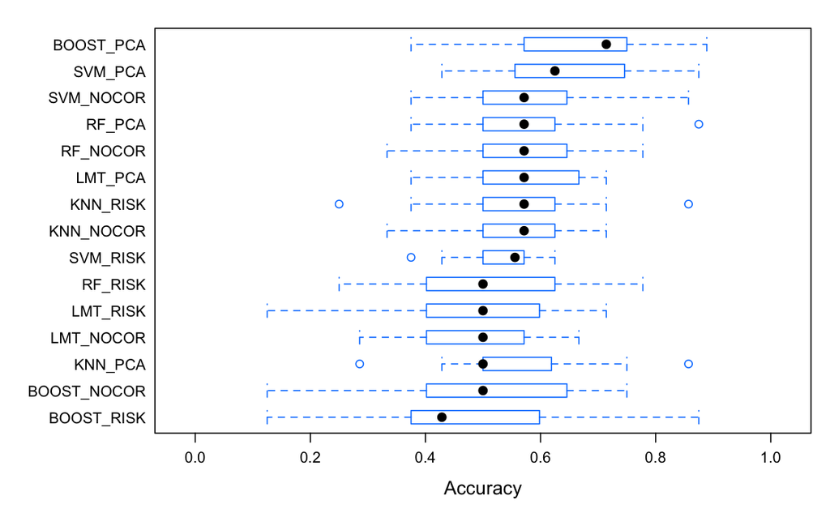

```r
scales <- list(x=list(relation="free"), y=list(relation="free"))
bwplot(results, scales=scales, metric = results$metrics[1], xlim = c(0, 1))
```

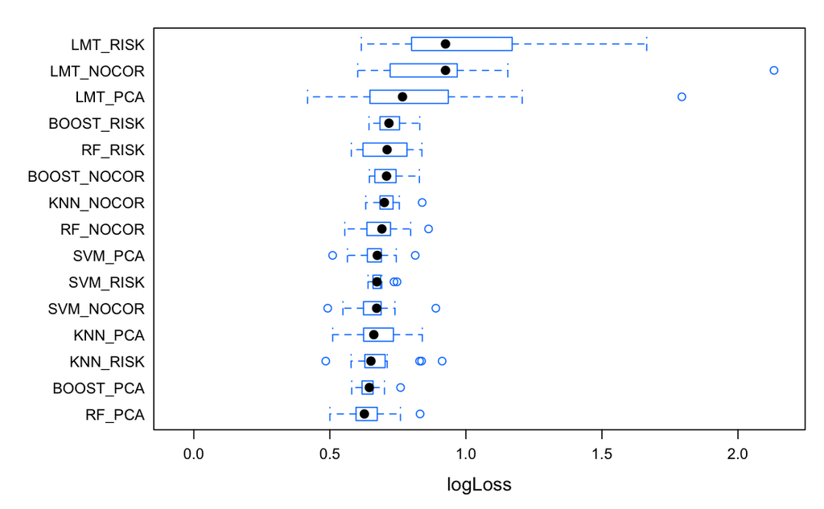

```r
bwplot(results, scales=scales, metric = results$metrics[6], xlim = c(0, 2.1))
```

```r
diffs <- diff(results)
print('P-value test of the prediction metrics for PCA dataset')
```

```
[1] "P-value test of the prediction metrics for PCA dataset"
```

```r
summary_diffs <- summary(diffs)
print(summary_diffs$table$Accuracy)
```

```
            SVM_PCA   KNN_PCA     RF_PCA      BOOST_PCA   LMT_PCA     SVM_NOCOR   KNN_NOCOR   RF_NOCOR    BOOST_NOCOR LMT_NOCOR   SVM_RISK    KNN_RISK    RF_RISK
SVM_PCA     ""        " 0.086243" " 0.064286" "-0.012698" " 0.076455" " 0.051455" " 0.094841" " 0.077646" " 0.147222" " 0.150265" " 0.113624" " 0.080556" " 0.131217"
KNN_PCA     "1.00000" ""          "-0.021958" "-0.098942" "-0.009788" "-0.034788" " 0.008598" "-0.008598" " 0.060979" " 0.064021" " 0.027381" "-0.005688" " 0.044974"
RF_PCA      "1.00000" "1.00000"   ""          "-0.076984" " 0.012169" "-0.012831" " 0.030556" " 0.013360" " 0.082937" " 0.085979" " 0.049339" " 0.016270" " 0.066931"
BOOST_PCA   "1.00000" "1.00000"   "1.00000"   ""          " 0.089153" " 0.064153" " 0.107540" " 0.090344" " 0.159921" " 0.162963" " 0.126323" " 0.093254" " 0.143915"
LMT_PCA     "1.00000" "1.00000"   "1.00000"   "1.00000"   ""          "-0.025000" " 0.018386" " 0.001190" " 0.070767" " 0.073810" " 0.037169" " 0.004101" " 0.054762"
SVM_NOCOR   "1.00000" "1.00000"   "1.00000"   "1.00000"   "1.00000"   ""          " 0.043386" " 0.026190" " 0.095767" " 0.098810" " 0.062169" " 0.029101" " 0.079762"
KNN_NOCOR   "1.00000" "1.00000"   "1.00000"   "1.00000"   "1.00000"   "1.00000"   ""          "-0.017196" " 0.052381" " 0.055423" " 0.018783" "-0.014286" " 0.036376"
RF_NOCOR    "1.00000" "1.00000"   "1.00000"   "1.00000"   "1.00000"   "1.00000"   "1.00000"   ""          " 0.069577" " 0.072619" " 0.035979" " 0.002910" " 0.053571"
BOOST_NOCOR "0.75657" "1.00000"   "1.00000"   "1.00000"   "1.00000"   "1.00000"   "1.00000"   "1.00000"   ""          " 0.003042" "-0.033598" "-0.066667" "-0.016005"
LMT_NOCOR   "0.05527" "1.00000"   "1.00000"   "0.72348"   "1.00000"   "1.00000"   "1.00000"   "1.00000"   "1.00000"   ""          "-0.036640" "-0.069709" "-0.019048"
SVM_RISK    "0.43445" "1.00000"   "1.00000"   "0.61181"   "1.00000"   "1.00000"   "1.00000"   "1.00000"   "1.00000"   "1.00000"   ""          "-0.033069" " 0.017593"
KNN_RISK    "1.00000" "1.00000"   "1.00000"   "1.00000"   "1.00000"   "1.00000"   "1.00000"   "1.00000"   "1.00000"   "1.00000"   "1.00000"   ""          " 0.050661"
RF_RISK     "1.00000" "1.00000"   "1.00000"   "1.00000"   "1.00000"   "1.00000"   "1.00000"   "1.00000"   "1.00000"   "1.00000"   "1.00000"   "1.00000"   ""
BOOST_RISK  "0.17720" "1.00000"   "1.00000"   "1.00000"   "1.00000"   "1.00000"   "1.00000"   "1.00000"   "1.00000"   "1.00000"   "1.00000"   "1.00000"   "1.00000"
LMT_RISK    "0.48473" "1.00000"   "1.00000"   "1.00000"   "1.00000"   "1.00000"   "1.00000"   "1.00000"   "1.00000"   "1.00000"   "1.00000"   "1.00000"   "1.00000"
            BOOST_RISK  LMT_RISK
SVM_PCA     " 0.161111" " 0.156481"
KNN_PCA     " 0.074868" " 0.070238"
RF_PCA      " 0.096825" " 0.092196"
BOOST_PCA   " 0.173810" " 0.169180"
LMT_PCA     " 0.084656" " 0.080026"
SVM_NOCOR   " 0.109656" " 0.105026"
KNN_NOCOR   " 0.066270" " 0.061640"
RF_NOCOR    " 0.083466" " 0.078836"
BOOST_NOCOR " 0.013889" " 0.009259"
LMT_NOCOR   " 0.010847" " 0.006217"
SVM_RISK    " 0.047487" " 0.042857"
KNN_RISK    " 0.080556" " 0.075926"
RF_RISK     " 0.029894" " 0.025265"
BOOST_RISK  ""          "-0.004630"
LMT_RISK    "1.00000"   ""
```